# Linear Regression

Alex Aronson

2022-11-06

### **Part 1**

- Suppose we have a data set with five predictors, X1 = GPA, X2 = IQ, X3 = Level (1 for College and 0 for High School), X4 = Interaction between GPA and IQ, and X5 = Interaction between GPA and Level. The response is starting salary after graduation (in thousands of dollars). Suppose that we fitted a model and got the following coefficients: βˆ0 = 50, βˆ1 = 20, βˆ2 = 0.07, βˆ3 = 35, βˆ4 = 0.01, βˆ5 = −10.

**1. Which answer is correct, and why?**

a.For a fixed value of IQ and GPA, high school graduates earn more, on average, than college graduates.

b.For a fixed value of IQ and GPA, college graduates earn more, on average, than high school graduates.

c.For a fixed value of IQ and GPA, high school graduates earn more, on average, than college graduates provided that the GPA is high enough.

d.For a fixed value of IQ and GPA, college graduates earn more, on average, than high school graduates provided that the GPA is high enough.

- The correct answer is C. When looking at least squares regression equations for both cases of levels (aka College or High school), we get equations

$YHS = \beta_0 + \beta_1X_1 + \beta_2X_2 +\beta_30 + \beta_4X_1X_2 +\beta_5X_10$

and

$YCOL = \beta_0 + \beta_1X_1 + \beta_2X_2 +\beta_3X_3 + \beta_4X_1X_2 +\beta_5X_1X_3$

- **X3 for YHS has a value of 0 and for YCOL has a value of 1**

We get the conclusion that college graduates make $35-10X_1$ more than high school graduates on average, however a higher gpa for college grads would mean a lower salary, so salary is conditional.

**2. Predict the salary of a college graduate with IQ of 110 and a GPA of 4.0**

- Using values given we get the equation:

$Salary =50 + 20(4.0)+ 0.07(110)+35+0.01(110(4.0))-10(4)=137(thousands)$

**3. True or false: Since the coefficient for the GPA/IQ interaction term is very small, there is very little evidence of an interaction effect. Justify your answer.**

- False, regardless of the size of the interaction coefficient, the effect is easily swayed due to its taking into account of two variables. Meaning little changes can have a big effect on the model itself.

### **Part 2**

```r
mtcars<- read.csv("mtcars.csv")
head(mtcars)
```

```
##                name  mpg cyl disp  hp drat    wt  qsec vs am gear carb
## 1         Mazda RX4 21.0   6  160 110 3.90 2.620 16.46  0  1    4    4
## 2     Mazda RX4 Wag 21.0   6  160 110 3.90 2.875 17.02  0  1    4    4
## 3        Datsun 710 22.8   4  108  93 3.85 2.320 18.61  1  1    4    1
## 4    Hornet 4 Drive 21.4   6  258 110 3.08 3.215 19.44  1  0    3    1
## 5 Hornet Sportabout 18.7   8  360 175 3.15 3.440 17.02  0  0    3    2
## 6           Valiant 18.1   6  225 105 2.76 3.460 20.22  1  0    3    1
```

```r
str(mtcars)
```

```
## 'data.frame':    41 obs. of  12 variables:
##  $ name: chr  "Mazda RX4" "Mazda RX4 Wag" "Datsun 710" "Hornet 4 Drive" ...
##  $ mpg : num  21 21 22.8 21.4 18.7 18.1 14.3 24.4 22.8 19.2 ...
##  $ cyl : int  6 6 4 6 8 6 8 4 4 6 ...
##  $ disp: num  160 160 108 258 360 ...
##  $ hp  : int  110 110 93 110 175 105 245 62 95 123 ...
##  $ drat: num  3.9 3.9 3.85 3.08 3.15 2.76 3.21 3.69 3.92 3.92 ...
##  $ wt  : num  2.62 2.88 2.32 3.21 3.44 ...
##  $ qsec: num  16.5 17 18.6 19.4 17 ...
##  $ vs  : int  0 0 1 1 0 1 0 1 1 1 ...
##  $ am  : int  1 1 1 0 0 0 0 0 0 0 ...
##  $ gear: int  4 4 4 3 3 3 3 4 4 4 ...
##  $ carb: int  4 4 1 1 2 1 4 2 2 4 ...
```

**1. Use the lm() function to perform a simple linear regression with the response mpg and the predictor hp.**

```r
LM1<- lm(mpg~hp, data=mtcars)
summary(LM1)
```

```
##
## Call:
## lm(formula = mpg ~ hp, data = mtcars)
##
## Residuals:
##     Min      1Q  Median      3Q     Max
## -5.6657 -1.2794 -0.7977  0.8162  8.7977
##
## Coefficients:
##              Estimate Std. Error t value Pr(>|t|)
## (Intercept) 29.297928   1.314115  22.295  < 2e-16 ***
## hp          -0.064548   0.008429  -7.658 2.72e-09 ***
## ---
## Signif. codes:  0 '***' 0.001 '**' 0.01 '*' 0.05 '.' 0.1 ' ' 1
##
## Residual standard error: 3.5 on 39 degrees of freedom
## Multiple R-squared:  0.6006, Adjusted R-squared:  0.5904
## F-statistic: 58.65 on 1 and 39 DF,  p-value: 2.723e-09
```

**2. Is there a relationship between the target mpg and predictor hp?**

- Yes there is a relationship between the mpg and the hp of the vehicle based on the P-values which is nearly 0.

**4. Is the relationship between mpg and hp positive or negative?**

- The relationship is negative due to the coefficent being negative, if we were to plug it in to exp(-0.064548)-1 = -0.063 roughly. Meaning for every horsepower increase there is a 0.063 mpg decrease.

**5. What is the predicted mpg associated with a horsepower (hp) of 100?**

```r
predict(LM1, data.frame(hp=c(100)), interval= "confidence")
```

```
##        fit     lwr      upr
## 1 22.84317 21.5279 24.15844
```

```r
predict(LM1, data.frame(hp =c(100)), interval= "prediction")
```

```
##        fit      lwr      upr
## 1 22.84317 15.64211 30.04423
```

- We can see that the predicted mpg for both the confidence interval and the prediction interval is roughly 23 mpg, however the intervals between the two differ.

**6. Plot the response and the predictor and add the regression line using abline()**

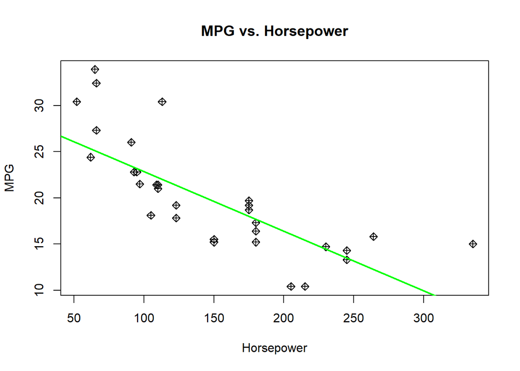

```r
plot(mpg~hp, main= "MPG vs. Horsepower", xlab = "Horsepower", ylab="MPG",data=mtcars, pch =9)
abline(coef = coef(LM1),lwd = 2, col= "green" )
```

**7.Perform a multiple linear regression with mpg as the response and the predictors cyl, disp, hp, wt, vs, and gear. Print out the results using summary() function.**

```r
LM2<- lm(mpg~cyl + disp + hp + wt + vs + gear, data = mtcars)
summary(LM2)
```

```
##
## Call:
## lm(formula = mpg ~ cyl + disp + hp + wt + vs + gear, data = mtcars)
##
## Residuals:
##     Min      1Q  Median      3Q     Max
## -2.5877 -1.8021 -0.3745  0.8538  6.3448
##
## Coefficients:
##             Estimate Std. Error t value Pr(>|t|)
## (Intercept) 33.29705    6.58333   5.058 1.45e-05 ***
## cyl         -0.74909    0.74433  -1.006  0.32133
## disp         0.01733    0.01086   1.596  0.11981
## hp          -0.03352    0.01381  -2.428  0.02061 *
## wt          -3.85230    0.88681  -4.344  0.00012 ***
## vs           0.70816    1.39192   0.509  0.61420
## gear         1.14054    0.95373   1.196  0.24002
## ---
## Signif. codes:  0 '***' 0.001 '**' 0.01 '*' 0.05 '.' 0.1 ' ' 1
##
## Residual standard error: 2.348 on 34 degrees of freedom
## Multiple R-squared:  0.8433, Adjusted R-squared:  0.8157
## F-statistic:  30.5 on 6 and 34 DF,  p-value: 2.568e-12
```

**10. Use * symbols to fit linear regression models with interaction effects between hp and wt. Does this interaction appear to be statistically significant?**

```r
LM3<- lm(mpg~cyl + disp + hp*wt + vs + gear, data = mtcars)
summary(LM3)
```

```
##
## Call:
## lm(formula = mpg ~ cyl + disp + hp * wt + vs + gear, data = mtcars)
##
## Residuals:
##     Min      1Q  Median      3Q     Max
## -2.5923 -1.3296 -0.0746  1.5702  4.7377
##
## Coefficients:
##              Estimate Std. Error t value Pr(>|t|)
## (Intercept) 39.114718   5.904910   6.624 1.56e-07 ***
## cyl          0.446579   0.723839   0.617 0.541495
## disp         0.009477   0.009618   0.985 0.331631
## hp          -0.129791   0.029475  -4.403 0.000106 ***
## wt          -7.888791   1.364880  -5.780 1.85e-06 ***
## vs           1.829641   1.240436   1.475 0.149691
## gear         1.547655   0.830101   1.864 0.071179 .
## hp:wt        0.026975   0.007556   3.570 0.001119 **
## ---
## Signif. codes:  0 '***' 0.001 '**' 0.01 '*' 0.05 '.' 0.1 ' ' 1
##
## Residual standard error: 2.024 on 33 degrees of freedom
## Multiple R-squared:  0.887,  Adjusted R-squared:  0.863
## F-statistic: 36.99 on 7 and 33 DF,  p-value: 7.699e-14
```

-Yes we can say that the interaction between horsepower and weight are statistically significant because 0.001119 < 0.05 significance level general rule.